# etrm: Energy Trading and Risk Management in R

## 2 Energy market forward price curves

The standardised forwards for electricity and gas are contracts for flow delivery. The underlying commodity is not received at a fixed point in time, but over a time interval. In mature markets, participants can trade a variety of products, both over-the-counter (OTC) and on exchanges such as [Nasdaq Commodities](https://www.nasdaq.com/solutions/european-commodities), [European Energy Exchange](https://www.eex.com/en/) and the [Intercontinental Exchange](https://www.theice.com/index). Liquidity is often best in the so called front-products, and there is normally higher activity in contracts for next week, month, quarter and year compared to similar products further ahead in time. Shorter period contracts may not even be available on a longer horizon, and seasonal price variation is thus not directly observable in prices far ahead in time. Transacted volume and prices also inhibit quite pronounced seasonality, during the year, week and within a specific day. For this reason, forward contracts are divided into categories based on a *load pattern*. In the *base load* contracts, volume is delivered at a constant rate during the contract period, while *peak load* products are linked to high volume hours, such as Monday to Friday from 8 am to 8 pm. Other, more exotic load patterns exist, but they are less common. Further details can be found in Eydeland and Wolyniec (2002) and Kirschen and Strbac (2018).

The aim of the energy market forward price curve calculation is to create a compact representation of the forward market, at a given point in time. The curve must be able to price the quoted instruments correctly, while accounting for typical energy market characteristics such as seasonality and (possibly overlapping) contracts for flow delivery. The curve is an essential decision making tool with many uses, such as pricing non-standard supply agreements, investment decisions and risk management.

The topic of forward curve fitting has been studied for decades in interest rate markets, see for example McCulloch (1971) and Anderson et al. (1996). These techniques cannot be applied directly to commodities with flow delivery and strong seasonality in prices. There are several alternative approaches to calculating a forward price curve for energy commodities. In Fleten and Lemming (2003), market data is combined with forecasts generated by a bottom-up model constrained by the bid/ask spread in order to meet the no-arbitrage condition. Borak and Weron (2008) propose a semiparametric factor model for the forward curve dynamics in electricity markets, while Hildmann et al. (2012) develop a calculation method by combining parametric estimation and prediction of futures prices under constraints.

In [*etrm*](https://CRAN.R-project.org/package=etrm), we have opted for a method that combines a seasonal function with the maximum smoothness-approach from interest rate markets, see Adams and Van Deventer (1994). Hence, we follow the approach in Ollmar (2003) and Benth et al. (2007b). *Base load* contracts are used to calculate a curve with daily granularity. This method has several benefits. It produces a continuous curve which has a closed form solution, it is fast to calculate, flexible and used by many practitioners in the industry. The next section provide a brief overview of the method, followed by a description of the [*etrm*](https://CRAN.R-project.org/package=etrm) implementation with examples.

### 2.1 Maximum smoothness forward curve model

Consider a market at time $t$ with $m$ forward contracts available for trading. Let the list
$$S_t=\left\{{(\tau^s_1,\tau^e_1),(\tau^s_2,\tau^e_2),...,(\tau^s_m,\tau^e_m)}\right\}$$
contain the start and end dates for each of these contracts. The time distance between $\tau^s_i$ and $\tau^e_i$ for a contract $i$ in $1, .., m$ cover standardized periods such as *week*, *month*, *quarter* and *year*. Some of these settlement intervals might overlap, and in order to handle this we create a new list of dates $\left\{t_0,t_1,...,t_n\right\}$ to identify each separate sub period, see Figure 1. The new list is made by sorting all dates in $S_t$ in ascending order and removing duplicates.

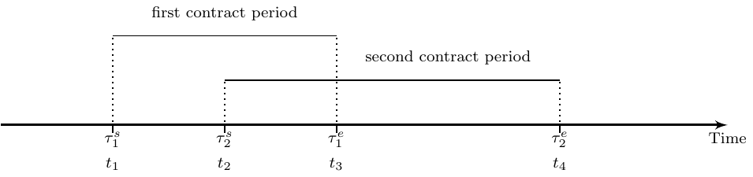

Figure 1: Illustration of two overlapping contracts with start ($\tau^s$) and end ($\tau^e$) dates. Due to the overlap, the total delivery period is split into sub intervals identified with $\left\{t_1,t_2,t_3,t_4\right\}$.

The forward price at time $t$ for one unit of energy delivered at a constant rate $(\tau^e-\tau^s)^{-1}$ over the time interval $(\tau^s,\tau^e)$ is denoted by $F(t,\tau^s,\tau^e)$, where $t\leq\tau^s<\tau^e$. A forward contract for a flow delivery may be thought of as the average of hypothetical single-delivery contracts. At time t, each of these would have a unique price $f(t,u)$ for the delivery at u with an infinitesimal delivery period. This leads to $F(t,\tau^s,\tau^e)$ being the weighted average
$$\label{fwdprice}
F(t,\tau_s,\tau_e)=\int\limits_{\tau^s}^{\tau^e}{w(u, \tau_s, \tau_e) f(t,u)}\,\mathrm{d}u \tag{1}$$
where $w(u, \tau_s, \tau_e) = \frac{\hat{w}(u)}{\int_{\tau_s}^{\tau_e}\hat{w}(v) dv}$ is a weight function accounting for the rate of interest $r$ and the time value of money. If the contract in question is settled at the end of the delivery period (forward contract), the weight function is given by $w(u, \tau_s, \tau_e) = 1/(\tau_e-\tau_s)$. If the contract is settled continuously over the delivery period (futures contract), $w(u, \tau_s, \tau_e) = \frac{re^{-ru}}{e^{-r\tau_s}-e^{-r\tau_e}}$. In the following we construct a forward market price curve for the entire horizon using a simplified notation $f(u)$ for the function describing the forward curve at time t. In order to model the strong seasonality in energy markets, the forward curve function is decomposed into two elements:

$$f(u)=\Lambda(u) + \epsilon(u) \qquad {u \in [t_0,t_n] }$$

$$\label{quadmin}
\min_{x}{\int\limits_{\tau^s}^{\tau^e}{[\epsilon''(u;x)]^2}\,\mathrm{d}u}\ \tag{2}$$

subject to

$$\begin{aligned}
(a_{j+1}-a_{j})u_j^4+(b_{j+1}-b_{j})u_j^3+(c_{j+1}-c_{j})u_j^2+(d_{j+1}-d_{j})u_j+e_{j+1}-e_j & = & 0 \label{knotcont} \\
\end{aligned} \tag{3}$$

$$\begin{aligned}
4(a_{j+1}-a_{j})u_j^3+3(b_{j+1}-b_{j})u_j^2+2(c_{j+1}-c_{j})u_j+(d_{j+1}-d_{j}) & = & 0 \label{diffknotcont} \\
\end{aligned} \tag{4}$$

$$\begin{aligned}
12(a_{j+1}-a_{j})u_j^2+6(b_{j+1}-b_{j})u_j+2(c_{j+1}-c_{j}) & = & 0 \label{diff2knotcont}\\
\end{aligned} \tag{5}$$

$$\begin{aligned}
\epsilon'(u_n;x) & = & 0 \label{horizontal}\\
\end{aligned} \tag{6}$$

$$\begin{aligned}
\frac{1}{\tau^e_i-\tau^s_i}\int\limits_{\tau^s_i}^{\tau^e_i}{(\Lambda(u)+\epsilon(u))}\,\mathrm{d}u & = & F^c_i \label{closing}
\end{aligned} \tag{7}$$

for spline knot $j = 1, ..., n-1$ and contract $i = 1, ..., m$. The constraint in (3) ensures the adjustment function is continuous in the knots, while (4) and (5) imposes this restriction also for the first and second order differentials. The (6) constraint require the adjustment function to be horizontal at time $T$, and finally (7) also require the average value of the forward price function $f(u)$ over the delivery period for contract $i$ to match the quoted closing price $F^c_i$. Here, we could take the interest rate effect from $r$ into account and set the present value of the average of the forward price function equal to present value of the forward contract. Instead of doing that, we will follow Benth et al. (2008) and Ollmar (2003) and assume $r=0$ such that the weight function in (1) is approximated with $w(u,\tau^s,\tau^e)\approx\frac{1}{\tau^e-\tau^s}$. Like Benth et al. (2008) we will argue that both the prior and the smoothing will outweigh a marginal interest rate effect. This minimisation problem can be expressed as

$$\min_{\mathbf{x}} \quad {\mathbf{x}^\intercal \mathbf{Hx}},$$
where $\textbf{x}$ is a $(5n \times 1)$ vector and

$$\textbf{H} =
\begin{bmatrix}
h_1 & & 0 \\
& \ddots & \\
0 & & h_n
\end{bmatrix},
\textbf{h}_j =
\begin{bmatrix}
\frac{144}{5}\Delta^5_j & 18\Delta^4_j & 8\Delta^3_j & 0 & 0 \\
18\Delta^4_j & 12\Delta^3_j & 6\Delta^2_j & 0 & 0 \\
8\Delta^3_j & 6\Delta^2_j & 4\Delta_j & 0 & 0 \\
0 & 0 & 0 & 0 & 0\\
0 & 0 & 0 & 0 & 0\\
\end{bmatrix}$$
The block diagonal matrix $\textbf{H}$ has dimensions $(5n\times5n)$ and $\Delta_j = t^l_{j+1}-t^l_{j}$. As the constraints in (2) are all linear in $x$ and may be expressed on the form $\boldsymbol{Ax}=\boldsymbol{B}$, the problem may be rephrased as an unconstrained minimisation problem via the Lagrange multiplier method:

$$\min_{\mathbf{x},\boldsymbol{\lambda}} \quad \boldsymbol{x^\intercal Hx + \lambda^\intercal(Ax-B)}$$

where $\mathbf{A}$ is a $(3n+m -2 \times 5n)$ matrix and $\mathbf{B}$ is a $(3n+m-2 \times 1)$ vector. The spline parameter vector and Lagrange multipliers are identified by solving

$$\begin{bmatrix}
\mathbf{2H} & \mathbf{A^\intercal} \\
\mathbf{A} & \mathbf{0}
\end{bmatrix}
\begin{bmatrix}
\mathbf{x} \\
\boldsymbol{\lambda}
\end{bmatrix}
=
\begin{bmatrix}
\mathbf{0} \\
\mathbf{B}
\end{bmatrix}$$

where the left matrix has dimension of $(8n+m-2) \times (8n+m-2)$ and both vectors are of dimension $(8n+m-2)$.

### 2.2 The "MSFC" class with examples

The forward curve calculation in [*etrm*](https://CRAN.R-project.org/package=etrm) is implemented in the S4 `"MSFC"` class. By supplying all required arguments to the constructor function `msfc()`, the user may create an object that contains the calculation results, input arguments and further calculation details. In addition to the arguments from the list of contracts, the user may also provide a prior to the calculation. By default the prior is set to zero, but the user can input any vector expressing a belief regarding the market to be combined with the observed prices. An overview of the `msfc()` arguments can be found in Table 1.

Table 1: Arguments for the `msfc()` constructor function for forward curve calculation.

| **Argument** | **Description** | **Default value** |
| --- | --- | --- |
| `tdate` | Trading date | none |
| `include` | Logical vector for contract selection | none |
| `contract` | Character vector with contract names | none |
| `sdate` | Date vector with contract start dates | none |
| `edate` | Date vector with contract end dates | none |
| `f` | Numeric vector with contract prices | none |
| `prior` | Numeric prior curve vector | 0 |

The `"MSFC"` class properties and available methods are summarised in Figure 2, and a brief description is provided in the following. The `"Name"` slot describe the type of forward curve model used by storing the character value "MSFC", while `"TradeDate"` keeps the trade date used in the calculation. A data frame containing details for selected contracts along with the calculated forward price based on the curve can be found in `"BenchSheet"`. A count of the $(n-1)$ number of polynomials used in the spline is available as a scalar value in `"Polynomials"`, and the prior curve vector in `"PriorFunc"`. The main calculation result is stored in a data frame which contains daily values for all selected contracts along with the calculated forward curve. The data frame span the date range from `"TradeDate"` to the end date of the contract furthest ahead in time, and can be found in `"Results"`. The interested user may also extract additional information regarding the spline itself. Coefficients for all polynomials can be found in the `"SplineCoef"` list and the knotpoints separating them in the numeric vector `"KnotPoints"`. Further details regarding the calculation of the daily forward curve values are available in the `"CalcDat"` data frame. This table is essentially an extended version of `"Results"`, where numeric time vectors and the spline coefficients have been added.

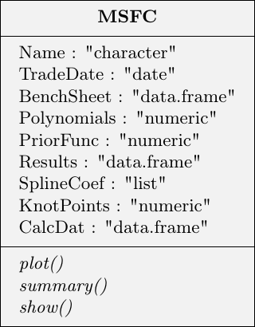

Figure 2: Attributes and methods of the `"MSFC"` class.

The `"MSFC"` class has the generic methods `plot()`, `summary()` and `show()`. The `plot()` method may be used to create a chart of the calculated curve and underlying contracts from the `"Results"` data frame. All plot methods in [*etrm*](https://CRAN.R-project.org/package=etrm) are based on [*ggplot2*](https://CRAN.R-project.org/package=ggplot2), see Wickham (2011a). The `summary()` method returns a list with three elements; a description string, a sample of the prior vector, and the bench sheet. Finally, the `show()` method returns the `"Results"` data frame.

We proceed with a practical example using two of the embedded [*etrm*](https://CRAN.R-project.org/package=etrm) data sets to represent information available to a European power market participant. All market-related inputs to the `msfc()` constructor (trade date and contract properties) are required arguments. These are collected from a synthetic data set for the trading date 2013-05-13, and can be found in `"powfutures130513"` presented in Table 2. Contracts covering long time spans are excluded with `include = FALSE` if futures of shorter duration are available for the same time interval in order to preserve the seasonality available in market prices. We use a seasonal prior with high energy prices during the winter season, followed by a drop toward the lower summer levels. It also take into account some well known calendar effects, such as weekends. The prior is simple, and merely used for illustrative purposes. It can be found in the data set `"powpriors130513"` included in the package. A calculation excluding the prior is also added for comparison.

Table 2: Closing prices for futures contracts used in the forward curve calculation for 2013-05-13. Contracts are selected for the calculations with the `include` vector. Prices for these contracts can be found as horizontal lines in Figure 3

| **Include** | **Contract** | **Start** | **End** | **Closing** |  |
| --- | --- | --- | --- | --- | --- |
| TRUE | W21-13 | 2013-05-20 | 2013-05-26 | $33.65$ |  |
| TRUE | W22-13 | 2013-05-27 | 2013-06-02 | $35.77$ |  |
| TRUE | W23-13 | 2013-06-03 | 2013-06-09 | $36.58$ |  |
| TRUE | W24-13 | 2013-06-10 | 2013-06-16 | $35.93$ |  |
| TRUE | W25-13 | 2013-06-17 | 2013-06-23 | $33.14$ |  |
| TRUE | W26-13 | 2013-06-24 | 2013-06-30 | $34.16$ |  |
| FALSE | MJUN-13 | 2013-06-01 | 2013-06-30 | $35.35$ |  |
| TRUE | MJUL-13 | 2013-07-01 | 2013-07-31 | $33.14$ |  |
| TRUE | MAUG-13 | 2013-08-01 | 2013-08-31 | $35.72$ |  |
| TRUE | MSEP-13 | 2013-09-01 | 2013-09-30 | $38.41$ |  |
| TRUE | MOCT-13 | 2013-10-01 | 2013-10-31 | $38.81$ |  |
| TRUE | MNOV-13 | 2013-11-01 | 2013-11-30 | $40.94$ |  |
| FALSE | Q3-13 | 2013-07-01 | 2013-09-30 | $35.72$ |  |
| TRUE | Q4-13 | 2013-10-01 | 2013-12-31 | $40.53$ |  |
| TRUE | Q1-14 | 2014-01-01 | 2014-03-31 | $42.40$ |  |
| TRUE | Q2-14 | 2014-04-01 | 2014-06-30 | $33.39$ |  |
| TRUE | Q3-14 | 2014-07-01 | 2014-09-30 | $31.78$ |  |
| TRUE | Q4-14 | 2014-10-01 | 2014-12-31 | $38.25$ |  |
| TRUE | Q1-15 | 2015-01-01 | 2015-03-31 | $40.73$ |  |
| TRUE | Q2-15 | 2015-04-01 | 2015-06-30 | $32.64$ |  |
| TRUE | Q3-15 | 2015-07-01 | 2015-09-30 | $30.87$ |  |
| TRUE | Q4-15 | 2015-10-01 | 2015-12-31 | $37.22$ |  |
| FALSE | CAL-14 | 2014-01-01 | 2014-12-31 | $36.43$ |  |
| FALSE | CAL-15 | 2015-01-01 | 2015-12-31 | $35.12$ |  |
| TRUE | CAL-16 | 2016-01-01 | 2016-12-31 | $34.10$ |  |
| FALSE | CAL-17 | 2017-01-01 | 2017-12-31 | $35.22$ |  |
| FALSE | CAL-18 | 2018-01-01 | 2018-12-31 | $36.36$ |  |

As shown in Figure 3, the shorter contracts close in time to the trading date clearly reflect a seasonal pattern. This is typical in power markets, where weather and calendar effects have strong influence on transacted volume and price formation. On a longer horizon however, this information is not observable in market prices, as the quoted contracts cover longer time spans. This is where price data may be supplemented with prior knowledge in order to create a representation of the market consistent with both the underlying fundamentals and the listed contracts. The following code will create the `"MSFC"` objects and plot calculation results:

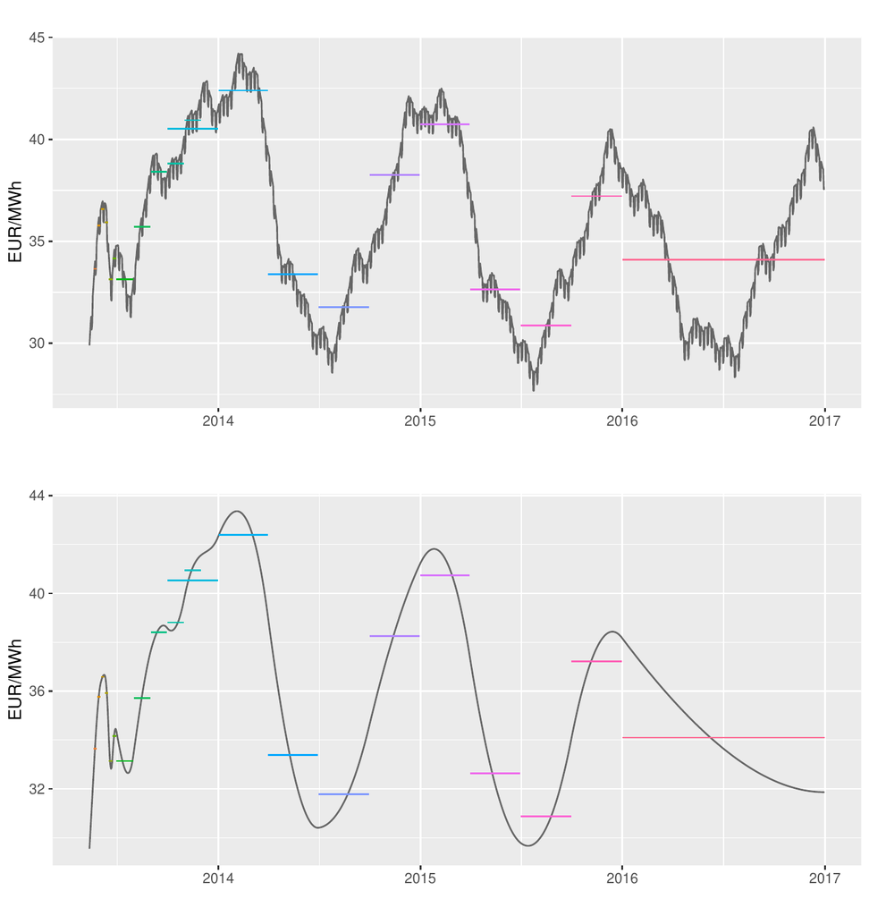

Figure 3: Two alternative forward curve calculations based on the same contract selection. In the top panel, a prior function is included in the calculation. This curve shows price variation on the weekly level, with lower prices during weekends. The prior also ensures that yearly seasonality is visible in the far end of the curve. The bottom plot is based solely on market prices, which does not reflect seasonality on such long horizon.

```r
library(etrm)
library(gridExtra)
data(powfutures130513)
data(powpriors130513)

# instance of MSFC class with prior
fwd.fut.wpri <- msfc(tdate = as.Date("2013-05-13"),
                     include = powfutures130513\$Include,
                     contract = powfutures130513\$Contract,
                     sdate = powfutures130513\$Start,
                     edate = powfutures130513\$End,
                     f = powfutures130513\$Closing,
                     prior = powpriors130513\$mod.prior)

# instance of MSFC class without prior
fwd.fut.npri <- msfc(tdate = as.Date("2013-05-13"),
                     include = powfutures130513\$Include,
                     contract = powfutures130513\$Contract,
                     sdate = powfutures130513\$Start,
                     edate = powfutures130513\$End,
                     f = powfutures130513\$Closing,
                     prior = 0)







# the generic plot() method
pw <- plot(fwd.fut.wpri, ylab = "EUR/MWh", legend = "")
pn <- plot(fwd.fut.npri, ylab = "EUR/MWh", legend = "")

# combine plots
gridExtra::grid.arrange(pw, pn)
```

The computed prices may be verified via the `summary()` method, which also return a sample of the prior and information regarding the spline calculation:

```r
> summary(fwd.fut.wpri)
\$Description
[1] "MSFC of length 1329 built with 41 polynomials at trade date 2013-05-13"

\$PriorFunc
[1] 30.10842 30.16396 30.19572 30.16144 29.06268 28.93272

\vspace{2cm}

\$BenchSheet
   Include Contract       From         To Price  Comp
1     TRUE   W21-13 2013-05-20 2013-05-26 33.65 33.65
2     TRUE   W22-13 2013-05-27 2013-06-02 35.77 35.77
3     TRUE   W23-13 2013-06-03 2013-06-09 36.58 36.58
4     TRUE   W24-13 2013-06-10 2013-06-16 35.93 35.93
5     TRUE   W25-13 2013-06-17 2013-06-23 33.14 33.14
6     TRUE   W26-13 2013-06-24 2013-06-30 34.16 34.16
8     TRUE  MJUL-13 2013-07-01 2013-07-31 33.14 33.14
9     TRUE  MAUG-13 2013-08-01 2013-08-31 35.72 35.72
10    TRUE  MSEP-13 2013-09-01 2013-09-30 38.41 38.41
11    TRUE  MOCT-13 2013-10-01 2013-10-31 38.81 38.81
12    TRUE  MNOV-13 2013-11-01 2013-11-30 40.94 40.94
14    TRUE    Q4-13 2013-10-01 2013-12-31 40.53 40.53
15    TRUE    Q1-14 2014-01-01 2014-03-31 42.40 42.40
16    TRUE    Q2-14 2014-04-01 2014-06-30 33.39 33.39
17    TRUE    Q3-14 2014-07-01 2014-09-30 31.78 31.78
18    TRUE    Q4-14 2014-10-01 2014-12-31 38.25 38.25
19    TRUE    Q1-15 2015-01-01 2015-03-31 40.73 40.73
20    TRUE    Q2-15 2015-04-01 2015-06-30 32.64 32.64
21    TRUE    Q3-15 2015-07-01 2015-09-30 30.87 30.87
22    TRUE    Q4-15 2015-10-01 2015-12-31 37.22 37.22
25    TRUE   CAL-16 2016-01-01 2016-12-31 34.10 34.10
```

The forward curve values can be extracted along with daily prices for the contracts used in the calculation with the `show()` method:

```r
> head(show(fwd.fut.wpri), 20)[1:5]
         Date     MSFC W21-13 W22-13 W23-13
1  2013-05-13 29.89373     NA     NA     NA
2  2013-05-14 30.40235     NA     NA     NA
3  2013-05-15 30.88704     NA     NA     NA
4  2013-05-16 31.30634     NA     NA     NA
5  2013-05-17 30.66200     NA     NA     NA
6  2013-05-18 30.98687     NA     NA     NA
7  2013-05-19 32.33591     NA     NA     NA
8  2013-05-20 32.74655  33.65     NA     NA
9  2013-05-21 33.19772  33.65     NA     NA
10 2013-05-22 33.63844  33.65     NA     NA
11 2013-05-23 34.02161  33.65     NA     NA
12 2013-05-24 33.34168  33.65     NA     NA
13 2013-05-25 33.62327  33.65     NA     NA
14 2013-05-26 34.91272  33.65     NA     NA
15 2013-05-27 35.24208     NA  35.77     NA
16 2013-05-28 35.59669     NA  35.77     NA
17 2013-05-29 35.92499     NA  35.77     NA
18 2013-05-30 36.17633     NA  35.77     NA
19 2013-05-31 35.34194     NA  35.77     NA
20 2013-06-01 35.44437     NA  35.77     NA
```

We have excluded columns from the data frame for the sake of presentation. Further details regarding the calculation such as spline coefficients and knot points can be found in the slots:

```r
> slotNames(fwd.fut.wpri)
[1] "Name"        "TradeDate"   "BenchSheet"
[4] "Polynomials" "PriorFunc"   "Results"
[7] "SplineCoef"  "KnotPoints"  "CalcDat"
```

See for example the numeric vector with knot points, measured in years from the trading date:

```r
> fwd.fut.npri@KnotPoints
 [1] 0.00000000 0.01917808 0.03561644 0.03835616 0.05479452 0.05753425 0.07397260
 [8] 0.07671233 0.09315068 0.09589041 0.11232877 0.11506849 0.13150685 0.13424658
[15] 0.21643836 0.21917808 0.30136986 0.30410959 0.38356164 0.38630137 0.46849315
[22] 0.47123288 0.55068493 0.63561644 0.63835616 0.88219178 0.88493151 1.13150685
[29] 1.13424658 1.38356164 1.38630137 1.63561644 1.63835616 1.88219178 1.88493151
[36] 2.13150685 2.13424658 2.38356164 2.38630137 2.63561644 2.63835616 3.63835616
```

The coefficients for the first polynomial in the adjustment function spline can be found with

```r
> fwd.fut.npri@SplineCoef[[1]]
[1] -355585.14451   10911.10580     -78.47028     151.90713      29.54903
```

The most elaborate presentation of the curve calculation is available in `fwd.fut.npri@CalcDat`. This slot contains a data frame with all calculation details for each of the daily values returned by `msfc()`. It is not included here due to space requirements.

## 3 Energy price risk management

Energy market participants may be exposed to number of risk factors such as volume, profile and basis risk, counter party defaults, foreign exchange and market liquidity, to name a few. See for example Eydeland and Wolyniec (2002) and Kirschen and Strbac (2018) for a comprehensive treatment of the topic. The main focus in [*etrm*](https://CRAN.R-project.org/package=etrm) is on the market price risk of the energy commodity. Consider the price risk associated with the constant base load volume $q$ to be delivered over a future time interval $(\tau^s, \tau^e)$. The risk can be mitigated by taking positions in the futures market during a trading period $(t_0, T)$, which ends before the actual delivery of the energy takes place at $T < \tau^s$.

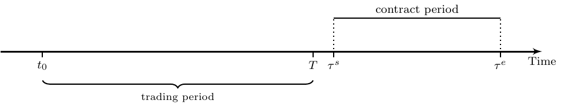

Figure 4: Trading and settlement periods for energy forward contract.

The price risk may be reduced by constructing a portfolio, consisting of the physical energy market exposure and derivatives contracts. The *portfolio price* per energy unit $p_t$ is calculated as the weighted average of the value of the transacted volumes and the open volume evaluated mark-to-market
$$%p_t= \frac{p_t^h\times h_t q + f_t\times q (1-h_t)}{q} = f_t + (p^h_t - f_t)\times h_t
%p_t & = \bigg[f_0 h_0 q + \sum_{i=1}^{t} f_i (h_i - h_{i-1}) q + f_t (1-h_t) q\bigg]/q \\
p_t = \frac{1}{q} \bigg(f_0 h_0 q + \sum_{i=1}^{t} f_i (h_i - h_{i-1}) q + f_t (1-h_t) q\bigg) = f_0 h_0 + \sum_{i=1}^{t} f_i (h_i - h_{i-1}) + f_t (1-h_t)$$
where $h_t\in(0,1)$ is the hedge rate and $f_t$ the futures price at time $t$. In the simplest possible scenario, the risk can be managed by locking the entire volume in the forward market. This removes the price risk and the portfolio owner knows up front what to pay or receive when delivery of the energy takes place. On the downside, one might regret locking if the market develops in a favourable way.

### 3.1 Portfolio insurance strategies

In the portfolio insurance approach, dynamic hedging strategies that allow buying and selling the hedging instrument are used to protect the portfolio, while seeking to benefit from advantageous market developments. Historically, the theory of portfolio insurance has focused on protection against downside risk in financial investment portfolios, see Leland and Rubinstein (1976) , Perold and Sharpe (1988) and Leland (1980). Here, we apply the same principles to manage commodity price risk in the forward market. A consumer following a dynamic hedging program may control price risk by locking a share of future volume in the futures market, and increase (decrease) the share if the price increase (falls). A seller can implement similar strategies to maximise value of the energy portfolio. The size of the initial hedged share and how it is adjusted affects both the protective properties of the hedging scheme as well as its ability to exploit opportunities in the market. Trading activity needs to be carefully managed and harmonized with overall objectives and risk preferences. A variety of portfolio insurance strategies offer different approaches to this task. The allocation strategies presented below all aim to control $p_t$ and prevent breach of a pre-specified cap (or floor) price, $p^*$, under the hedge rate restriction $h_t\in(0,1)$.

The **Constant proportion portfolio insurance (CPPI)** strategy was introduced by Perold (1986) and Black and Jones (1987) for management of investment portfolios with capital guarantees. When applied to an energy portfolio, it aims to insure the portfolio by protecting a target price, a cap (floor) value for the portfolio price. Prior to start of hedging, $p^*$ is set equal to the highest (lowest) acceptable portfolio price. This target price must be set higher than the first day’s market price $f_0$ to implement cap protection, or lower for a floor protection model. The difference between the target price and the current portfolio price is termed the cushion. The key idea of CPPI is that the proportion of the volume exposed to the market should be calculated as a constant multiple $m$ of the cushion. The multiple is given by $m=\mu^{-1}$, where $\mu>0$ is a risk factor set to handle the maximum daily price change to be handled by the hedging model, which again affects strategy gearing. The unexposed proportion, the hedge rate, is
$$h_t =
\begin{cases}
0 & \text{ if } \quad c_t > \mu\\
1-m c_t & \text{ if } \quad \mu \geq c_t\geq 0 \\
1 & \text{ if } \quad c_t< 0
\end{cases}$$
where $c_t=p^*-p_{t-1}$ for a short hedger, and $c_t=p_{t-1}-p^*$ for the long hedger.

In the **Dynamic proportion portfolio insurance (DPPI)** strategy, a decision rule similar to CPPI is applied, but the multiple $m_t$ is allowed to vary. Changing market conditions may require re-evaluation of the risk factor in the multiple. Methods such as Value-at-Risk or Expexted Shortfall, or even simple heuristics can be used for this purpose. For a further treatment of DPPI type strategies, the reader is referred to Lee et al. (2008) and Chen et al. (2008). In [*etrm*](https://CRAN.R-project.org/package=etrm) we also allow adjustments in the target price $p^*_t$, to catch opportunities to lower the capped value, or to increase the floor value. The hedge rate is determined similarly to CPPI, with
$$p^*_t =
\begin{cases}
min(\lambda p_{t-1},p^*_{t-1}) & \text{ short hedger }\\
\\
max(\lambda p_{t-1},p^*_{t-1}) & \text{ long hedger }
\end{cases}$$
where $\lambda = \frac{p^*_o}{p_o}$ for a short hedger, and $\lambda = \frac{p_o}{p^*_o}$ for the long hedger.

**Option based portfolio insurance (OBPI)** was first introduced in Leland and Rubinstein (1976) as a means of providing insurance for investment portfolios. By combining an investment in a risky asset with a put option on the asset, the portfolio value is prevented from falling below the option strike price, K. A similar approach can be taken for the energy portfolio. As we are using futures contracts to manage the energy price risk, the Black-76 formula introduced in Black (1976) is used to approximate the contingent claim premium. The price at time $t$ of the European call and put options with exercise date $T$ and strike price $K$, on a futures contract with delivery start $\tau^s \geq T$ is given by
$$\begin{aligned}
C(f_t, t, K, \sigma, r) &=& e^{-r (T-t)} [f_t N(d_1) - KN(d_2)]\\
P(f_t, t, K, \sigma, r) &=& e^{-r (T-t)} [KN(-d_2) - f_t N(-d_1)]
\end{aligned}$$
where $f_t$ is the futures price and $N$ is the cumulative distribution function of $N(0,1)$, where
$$\begin{aligned}
d_1 &=& \frac{\ln(f_t/K) + (\sigma^2/2)(T-t)}{\sigma\sqrt{(T-t)}}\\
d_2 &=& d_1 - \sigma\sqrt{(T-t)}
\end{aligned}$$
and $r$ is the risk free rate of interest, $\sigma$ the volatility of the underlying futures price and $(T-t)$ is the time to exercise date. The sensitivity in the option premiums with respect to changes in the underlying futures price is given by the call and put option deltas:
$$\begin{aligned}
\frac{\partial C}{\partial f} &=& e^{-r(T-t)}N(d_1)\\
\frac{\partial P}{\partial f} &=& e^{-r(T-t)}N(-d_1)
\end{aligned}$$
These are used to synthesise the option, by setting portfolio hedge rate $h_t\in(0,1)$ with the call (buyer) and put (seller) option deltas. By implementing this *delta hedging* scheme, a cap (floor) for the portfolio price is set at the option strike price $K$, adjusted for the option premium/ replication costs. For a more detailed presentation of the underlying theory, the reader is referred to Bjork (2009).

**Step hedge portfolio insurance (SHPI)** is a simple and mechanical benchmark strategy that builds hedging positions gradually by transacting identical volumes each day through the trading period $(t_0, T)$, reaching a full hedge prior to the start of the settlement period. The hedge rate for a buyer at time $t$ is given by

$$h_t =
\begin{cases}
\frac{t}{T-t_0 +1} & \text{ if } \quad p_t < p^*\\
1 & \text{ if } \quad p_t \geq p^* \\
\end{cases}$$
The hedges for a seller is entered mechanically in a similar manner as long as $p_t > p^*$. In the event $p_t \leq p^*$ a full hedge $h_t = 1$ is implemented. By distributing the transacted volumes evenly across the trading period while monitoring the target, the strategy portfolio price will either be locked in at the target price, or end up equal to the average forward market price over $(t_0, T)$.

Finally, the **Stop loss portfolio insurance (SLPI)** is another simple benchmark, where no hedge positions are entered unless the target level is reached. For a buyer, this may be expressed as

$$h_t =
\begin{cases}
0 & \text{ if } \quad p_t < p^*\\
1 & \text{ if } \quad p_t \geq p^* \\
\end{cases}$$
For a seller, the logic is reversed with $h_t=0$ for $p_t > p^*$ and $h_t=1$ for $p_t \leq p^*$. In the event that the target level is reached, the portfolio is kept fully hedged until start of settlement. If this does not occur, the portfolio follows the forward market, leaving an option to lock in the price at contract expiration.

The strategies presented above all have strengths and weaknesses. CPPI, SHPI and SLPI are simple and intuitive, but can be vulnerable to so-called *lock in*, the inability to improve portfolio price once the target level has been reached. This is also the case for DPPI. The OBPI does not suffer from this trait, but it relies on more assumptions regarding model parameters. In some scenarios, it will also generate more trading activity (costs), for example if the market fluctuate around the option strike price, $K$. Finally, as the strategies must be implemented in discrete time, they will all be exposed to gap risk.

### 3.2 The strategy classes with examples

The portfolio insurance strategies in [*etrm*](https://CRAN.R-project.org/package=etrm) are implemented as S4 classes. Since they share many characteristics, they inherit most of their properties from a parent class, `"GenericStrat"`. In fact, the implementation of the simple benchmark strategies SLPI and SHPI do not require any additional properties to be added to the parent. The remaining strategy classes have some additional model specific features, in accordance with the descriptions in previous section. This modular design offers flexibility, and new strategies for price risk management can easily be added to the package.

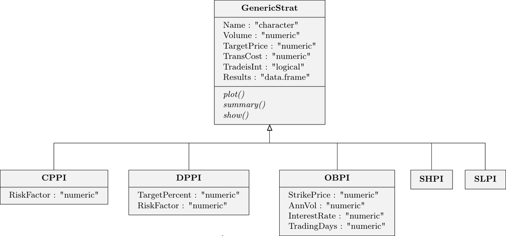

Figure 5: Attributes and methods for portfolio insurance strategy classes in the [*etrm*](https://CRAN.R-project.org/package=etrm) package.

Figure 5 provide an overview of the class hierarchy, and a brief description is given in the following. In `"GenericStrat"`, the `"Name"` property is used to store a strategy identifier. Allowed character values are "CPPI", "DPPI", "OBPI", "SHPI" and "SLPI". The volume to be managed and the corresponding price cap (floor) can be found in `"Volume"` and `"TargetPrice"`, respectively. If a transaction cost has been included in the calculation of the portfolio price, this is to be found in `"TransCost"`. One may also set a restriction on transactions by requiring that the smallest volume available for trading is equal to 1 unit. This lot size limitation is stored as TRUE/FALSE in `"TradeisInt"`. The main output from a strategy calculation can be found in `"Results"`. This data frame keeps daily values for market prices, transactions, exposed volume, open volume, hedge rate, target price and portfolio price.

The generic methods `plot()`, `summary()` and `show()` are implemented in `"GenericStrat"` and inherited by the strategy classes. The `plot()` method returns a chart based on `"Results"`, with daily values for portfolio, market and target prices and portfolio hedge rate. The `summary()` method returns a list with five elements; a description string, portfolio volume, target price, calculated churn rate and a data frame with summary statistics for the trading period. Finally, the `show()` method returns the `"Results"` data frame.

Table 3: Arguments shared by the portfolio insurance strategy functions.

| **Argument** | **Description** | **Default value** |
| --- | --- | --- |
| `q` | Numeric volume | none |
| `tdate` | Date vector with trading days | none |
| `f` | Numeric price vector | none |
| `tcost` | Numeric transaction cost | 0 |
| `int` | Logical lot size integer restriction | TRUE |

The strategy constructor functions `cppi()`, `dppi()`, `obpi()`, `shpi()` and `slpi()` share five of the arguments, see Table 3. Each strategy require some additional arguments to implement the models presented in previous section. All of these inputs are of `"numeric"` data type. They are summarised in Table 4.

Table 4: Model specific arguments for the portfolio insurance strategy functions.

| **Function** | **Argument** | **Description** | **Default value** |
| --- | --- | --- | --- |
| `cppi()` | `tper` | Target price factor | none |
|  | `rper` | Risk factor percentage | none |
| `dppi()` | `tper` | Target price factor | none |
|  | `rper` | Risk factor percentage | none |
| `obpi()` | `k` | Option strike price | $k=f_0$ |
|  | `vol` | Annualized volatility | none |
|  | `r` | Interest rate | 0 |
|  | `tdays` | Trading days per year | 250 |
|  | `daysleft` | Days left to expiry | none |
| `shpi()` | `tper` | Target price factor | none |
|  | `daysleft` | Days left to expiry | none |
| `slpi()` | `tper` | Target price factor | none |

To illustrate further, we proceed with an example. Consider a European consumer of electricity procuring 30 MW to be delivered in 2006. The CAL-06 baseload power future from the synthetic [*etrm*](https://CRAN.R-project.org/package=etrm) `"powcal"` data set is used as hedging instrument. Trading is started 500 days prior to the contract expiry, approximately a horizon of 2 years. For the `"OBPI"` strategy presented below, the target price is calculated as an expected price cap given by the option premium-adjusted strike price selected for the delta hedging scheme within a standard Black-76 option pricing framework. The default `obpi()` strike price is set at-the-money, in this case at 26.82 EUR/MWh. The expected target price illustrated with the horizontal dotted line in Figure 6 is calculated to be 29.84 EUR/MWh. The `"OBPI"` delta hedging scheme dictate an initial hedge rate of 57 percent, and the consumer enters a 17 MW position in CAL-06 on the first day of trading.

As time progresses and the market price changes, the `obpi()` function adjust the required hedge rate in order to replicate the call option on the CAL-06 contract. Hedge rate is gradually built up as the market increase from the second quarter of 2004, followed by a reduction after the sharp price drop starting late in the same year. Eventually, the volume is fully hedged due to the strong upwards price trend in 2005. The CAL-06 contract closes at 37.81 EUR/MWh on the expiry date, while the consumer has a hedge of 30 MW and a portfolio price of 29.29 EUR/MWh. The calculated price of the option to be synthesized (and the delta hedges) will depend on the Black-76 model parameters. In this example the risk free rate of interest is set to $r=0$ and annualized volatility $\sigma$ is assumed to be 20 percent. The following code will implement the strategy and create the plot in Figure 6:

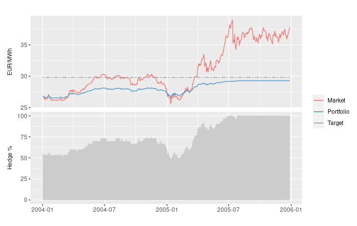

Figure 6: Option based portfolio insurance (OBPI) strategy for buyer CAL-06. Daily observations for prices (top panel) and hedge rate (bottom panel). As the market price continue to rise, the hedge rate is increased and the portfolio price is locked below the target price level.

```r
# data frame with final 500 trading days for CAL-06 contract
dat06 <- tail(na.omit(powcal[, c(1,2)]), 500)

# instance of the OBPI class
cal06_obpi_b <- obpi(q = 30,
           tdate = dat06\$Date,
           f = dat06\$`CAL-06`,
           k = dat06\$`CAL-06`[1],
           vol = 0.2,
           r = 0,
           tdays = 250,
           daysleft = 500,
           tcost = 0,
           int = TRUE)

# the generic plot() method
plot(cal06_obpi_b, title = "", legend = "right", ylab.1 = "EUR/MWh")
```

An aggregated view of the trading activity over the 2 year period and final results can be retrieved by running the `summary()` method on the object created above:

```r
> summary(cal06_obpi_b)
\$Description
[1] "Hedging strategy of type OBPI and length 500"

\$Volume
[1] 30

\$Target
[1] 29.83626

\$ChurnRate
[1] 4.333333


\$Stats
      Market Trade Exposed Position     Hedge   Target Portfolio
First  26.82    17      13       17 0.5666667 29.83626  26.82000
Max    39.01    17      17       30 1.0000000 29.83626  29.29433
Min    25.60    -3       0       13 0.4333333 29.83626  26.46833
Last   37.81     0       0       30 1.0000000 29.83626  29.29433
```

We note from the `"ChurnRate"` that the underlying 30 MW volume had to be traded 4.33 times in order to synthesize the call option and achieve the results summarised in `"Stats"`. By also considering the trading costs in the calculations, the user can get valuable inputs when considering alternatives, such as simply buying the option in the market. However, such contract may not always be available.

Finally, the `show()` method provide details regarding daily values for market price, transactions, exposed volume, futures contract position, hedge rate, the target price and the calculated portfolio price:

```r
> head(show(cal06_obpi_b))
        Date Market Trade Exposed Position     Hedge   Target Portfolio
1 2004-01-02  26.82    17      13       17 0.5666667 29.83626  26.82000
2 2004-01-05  26.63    -1      14       16 0.5333333 29.83626  26.73767
3 2004-01-07  26.31     0      14       16 0.5333333 29.83626  26.58833
4 2004-01-08  26.31     0      14       16 0.5333333 29.83626  26.58833
5 2004-01-09  26.54     0      14       16 0.5333333 29.83626  26.69567
6 2004-01-12  26.32     0      14       16 0.5333333 29.83626  26.59300
```

For the sake of comparison, the OBPI strategy for CAL-06 from a sellers point of view can be implemented with similar assumptions by setting the volume to $q = -30$. Using the default at-the-money strike price, the seller calculates an expected target floor to protect at 23.80 EUR/MWh and an initial hedge rate of 43 percent. As the market starts to rise, the hedge is reduced. The seller increases the hedge in late 2004 to dampen the effect from the market drop, and finally exits the forward market positions as the price increases during 2005. The portfolio price follows the market upwards with a premium for the put option replication, as expected for an insurance scheme. The CAL-06 contract closes at 37.81 EUR/MWh, and the seller has a portfolio price of 35.34 EUR/MWh, which may be locked in on the final trading day.

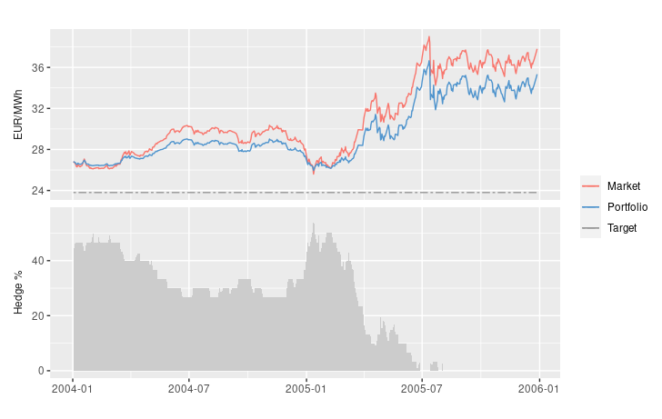

Figure 7: Option based portfolio insurance (OBPI) strategy for seller CAL-06. Daily observations for prices (top panel) and hedge rate (bottom panel). The hedge rate is lowered in the upwards trending market, and the portfolio price continue to increase.

```r
# instance of the OBPI class
cal06_obpi_s <- obpi(q = - 30,
           tdate = dat06\$Date,
           f = dat06\$`CAL-06`,
           k = dat06\$`CAL-06`[1],
           vol = 0.2,
           r = 0,
           tdays = 250,
           daysleft = 500,
           tcost = 0,
           int = TRUE)

# the generic plot() method
plot(cal06_obpi_s, title = "", legend = "right", ylab.1 = "EUR/MWh")
```

```r
> summary(cal06_obpi_s)
\$Description
[1] "Hedging strategy of type OBPI and length 500"

\$Volume
[1] -30

\$Target
[1] 23.80374

\$ChurnRate
[1] 4.2

\$Stats
      Market Trade Exposed Position     Hedge   Target Portfolio
First  26.82   -13     -17      -13 0.4333333 23.80374  26.82000
Max    39.01     2     -13        0 0.5666667 23.80374  36.64867
Min    25.60   -13     -30      -17 0.0000000 23.80374  25.95167
Last   37.81     0     -30        0 0.0000000 23.80374  35.33567
```

In the examples above, we have implicitly assumed that both the consumer and the seller have a flat volume corresponding to 30 MW over the entire year which can be covered by a base load contract such as the CAL-06. In practice, this is typically not the case. Industrial energy consumers will have consumption profiles determined by the activity level in their production facilities, and often face seasonal shifts due to variation in demand, or holidays. Weather also play a large role, both for consumers and producers such as hydroelectric plants. In order to hedge the predicted volume more precisely, some of the other contract types presented in Table 2 will need to be included in the portfolio. Market players will "roll forward" and start trading contracts covering shorter periods such as quarters, months and weeks, as they become available. The mandate for the energy portfolio will typically be broken down into smaller time intervals with expected volume and required hedge levels. All strategies presented here may be used to make decisions for several years and their sub periods, and the market value of a specific volume prognosis and corresponding futures positions can be evaluated using the forward curve discussed in previous sections.